# Use of insitutype in a small CosMx dataset

## Vignette to-dos:

- add section at end on mergecells function
- save clustering results in package data to save time when running?

### Installation

```r
# TBD
```

### Overview

This vignette demonstrates the use of the insitutype algorithm to perform cell typing of CosMx data.

We’ll analyze a subset of the CosMx NSCLC showcase dataset.

### Data preparation

First, we load the package and access the example data:

```r
library(MLEcell)
data("ioprofiles")
data("iocolors")
data("mini_nsclc")
str(mini_nsclc)
```

```
#> List of 5
#>  $ counts: num [1:2198, 1:960] 0 0 0 0 0 0 0 0 0 0 ...
#>   ..- attr(*, "dimnames")=List of 2
#>   .. ..$ : chr [1:2198] "c_3_18_2" "c_3_18_3" "c_3_18_4" "c_3_18_5" ...
#>   .. ..$ : chr [1:960] "AATK" "ABL1" "ABL2" "ACE" ...
#>  $ neg   : num [1:2198, 1:20] 0 0 0 0 0 0 0 0 0 0 ...
#>   ..- attr(*, "dimnames")=List of 2
#>   .. ..$ : chr [1:2198] "c_3_18_2" "c_3_18_3" "c_3_18_4" "c_3_18_5" ...
#>   .. ..$ : chr [1:20] "NegPrb3" "NegPrb6" "NegPrb15" "NegPrb18" ...
#>  $ x     : num [1:2198] 7.34 7.4 7.42 7.46 7.53 ...
#>  $ y     : num [1:2198] -6.5 -6.5 -6.5 -6.5 -6.5 ...
#>  $ umap  : num [1:2198, 1:2] 1.489 -0.774 -1.915 1.927 1.135 ...
#>   ..- attr(*, "dimnames")=List of 2
#>   .. ..$ : chr [1:2198] "c_3_18_2" "c_3_18_3" "c_3_18_4" "c_3_18_5" ...
#>   .. ..$ : NULL
```

```r
set.seed(0)
```

#### Unsupervised clustering:

Let’s begin with straightforward unsupervised clustering. We’ll let the algorithm try to select the optimal number of clusters from a range of plausible options.

[output not shown]

[output cut: 22 more lines]

```
#> ==========================================================================
#> phase 3: finalizing clusters in a 2000 cell subset
#> 1.19 cells per geometric bin.
#> iter 1
#> iter 2
#> iter 3
#> iter 4
#> iter 5
#> iter 6
#> iter 7
#> iter 8
#> iter 9
#> Converged: <= 0.01% of cell type assignments changed in the last iteration.
#> ==========================================================================
#> phase 4: classifying all 2198 cells
```

The function returns 3 useful outputs: a vector of cells’ cluster assignments, a matrix of cells’ probabilities of belonging to each cluster, and a matrix of the mean expression profile of each cluster.

```r
str(unsup)
```

```
#> List of 4
#>  $ clust   : chr [1:2198] "b" "b" "b" "b" ...
#>  $ probs   : num [1:2198, 1:10] 1 1 1 1 0 0 0 0.935 0 0 ...
#>   ..- attr(*, "dimnames")=List of 2
#>   .. ..$ : chr [1:2198] "c_3_18_2" "c_3_18_3" "c_3_18_4" "c_3_18_5" ...
#>   .. ..$ : chr [1:10] "b" "f" "e" "i" ...
#>  $ profiles: num [1:960, 1:10] 0 0 0.249 0.2378 0.0129 ...
#>   ..- attr(*, "dimnames")=List of 2
#>   .. ..$ : chr [1:960] "AATK" "ABL1" "ABL2" "ACE" ...
#>   .. ..$ : chr [1:10] "b" "f" "e" "i" ...
#>  $ anchors : NULL
```

```r
round(head(unsup$probs),2)
```

```
#>          b f e i d g j h c a
#> c_3_18_2 1 0 0 0 0 0 0 0 0 0
#> c_3_18_3 1 0 0 0 0 0 0 0 0 0
#> c_3_18_4 1 0 0 0 0 0 0 0 0 0
#> c_3_18_5 1 0 0 0 0 0 0 0 0 0
#> c_3_18_6 0 1 0 0 0 0 0 0 0 0
#> c_3_18_7 0 0 1 0 0 0 0 0 0 0
```

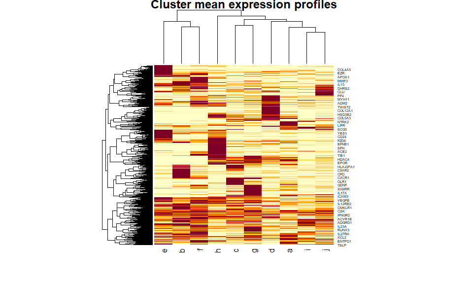

```r
heatmap(sweep(unsup$profiles, 1, apply(unsup$profiles, 1, max), "/"), scale = "none",
        main = "Cluster mean expression profiles")
```

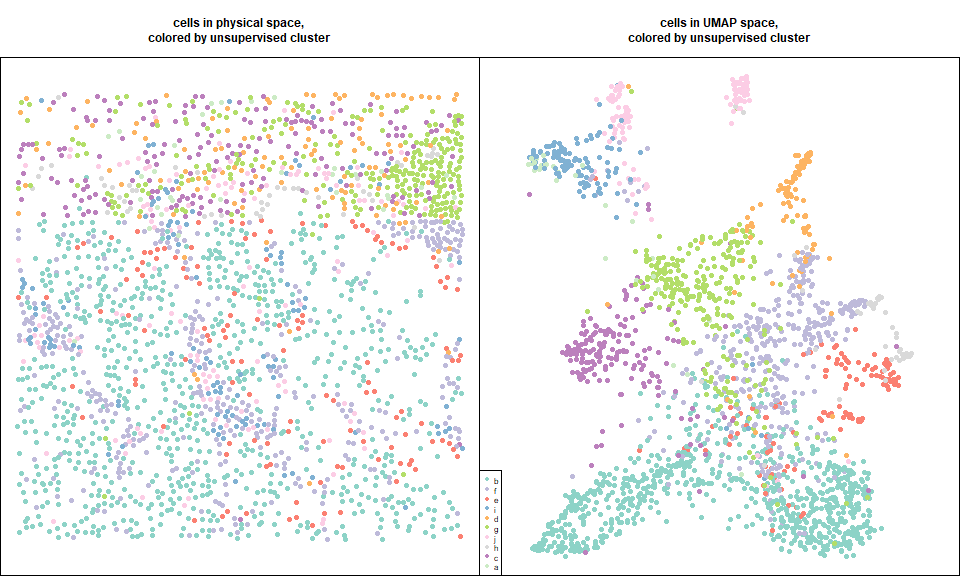

```r
# define cluster colors:
cols <- c('#8DD3C7','#BEBADA','#FB8072','#80B1D3','#FDB462','#B3DE69','#FCCDE5','#D9D9D9','#BC80BD','#CCEBC5','#FFED6F','#E41A1C','#377EB8','#4DAF4A','#984EA3','#FF7F00','#FFFF33','#A65628','#F781BF','#999999')
cols <- cols[seq_along(unique(unsup$clust))]
names(cols) <- unique(unsup$clust)

par(mfrow = c(1,2))
par(mar = c(0,0,3,0))

plot(mini_nsclc$x, mini_nsclc$y, pch = 16, cex = .75, asp = 1, cex.main = 0.75,
          main = "cells in physical space,\ncolored by unsupervised cluster",
     col = cols[unsup$clust], xlab = "", ylab = "", xaxt = "n", yaxt = "n")

plot(mini_nsclc$umap, pch = 16, cex = .75, asp = 1, cex.main = 0.75,
     main = "cells in UMAP space,\ncolored by unsupervised cluster",
     col = cols[unsup$clust], xlab = "", ylab = "", xaxt = "n", yaxt = "n")
legend("bottomleft", pch = 16, col = cols, legend = names(cols), cex = 0.5)
```

#### Supervised cell typing:

Often, expression profiles will be available ahead of time for the cell types present in a tissue. Cell type expression profiles could come from earlier scRNA-seq studies, from singel cell expression databases like the human cell atlas, or from databases of cell type profiles like https://github.com/Nanostring-Biostats/CellProfileLibrary or https://github.com/northstaratlas/atlas_landmarks.

When we already know the expression profile of cells in a tissue, we can skip unsupervised clustering and simply assign each cell to the cell type under which its expression data is most likely using the insitutypeML function. Below, we perform supervised cell typing using a matrix of immune cell profiles:

[output not shown]

Now let’s examine the results:

```r
str(sup)
```

```
#> List of 3
#>  $ clust  : chr [1:2198] "macrophage" "macrophage" "macrophage" "macrophage" ...
#>  $ probs  : num [1:2198, 1:16] 0 0 0 0 0 0 0 1 0 0 ...
#>   ..- attr(*, "dimnames")=List of 2
#>   .. ..$ : chr [1:2198] "c_3_18_2" "c_3_18_3" "c_3_18_4" "c_3_18_5" ...
#>   .. ..$ : chr [1:16] "B-cell" "endothelial" "fibroblast" "macrophage" ...
#>  $ logliks: num [1:2198, 1:16] -162 -194 -568 -190 -467 ...
#>   ..- attr(*, "dimnames")=List of 2
#>   .. ..$ : chr [1:2198] "c_3_18_2" "c_3_18_3" "c_3_18_4" "c_3_18_5" ...
#>   .. ..$ : chr [1:16] "B-cell" "endothelial" "fibroblast" "macrophage" ...
```

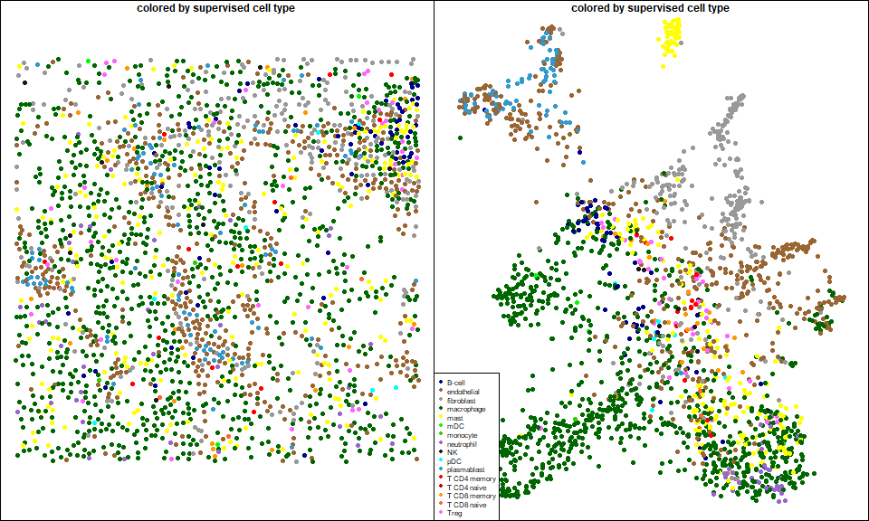

```r
par(mfrow = c(1,2))
par(mar = c(0,0,0,0))

plot(mini_nsclc$x, mini_nsclc$y, pch = 16, cex = .75, asp = 1, cex.main = 0.75,
     main = "cells in physical space,\ncolored by supervised cell type",
     col = iocolors[sup$clust], xlab = "", ylab = "", xaxt = "n", yaxt = "n")

plot(mini_nsclc$umap, pch = 16, cex = .75, asp = 1, cex.main = 0.75,
     main = "cells in UMAP space,\ncolored by supervised cell type",
     col = iocolors[sup$clust], xlab = "", ylab = "", xaxt = "n", yaxt = "n")
legend("bottomleft", pch = 16, col = iocolors, legend = names(iocolors), cex = 0.5)
```

There’s a problem with the above plot: this is a tumor sample, but the profile matrix only contains profiles for immune and stroma cells. Any tumor cells will get assigned to whichever immune or stroma cell fits them best.

#### Semi-supervised clustering

Below we’ll perform semi-supervised clustering of the NSCLC sample, looking for known immune and stroma cell types while also fitting new clusters, presumably tumor cells:

```r
semi <- insitutype(counts = mini_nsclc$counts,
                   neg = Matrix::rowMeans(mini_nsclc$neg),
                   init_clust = NULL,
                   n_clusts = 2,
                   fixed_profiles = ioprofiles,
                   anchors = NULL,
                   n_phase1 = 200, n_phase2 = 500, n_phase3 = 2000, # choosing inadvisably low numbers to speed the vignette
                   n_anchor_cells = 10,
                   nb_size = 10,
                   n_starts = 2)
```

```
#> automatically selecting anchor cells with the best fits to fixed profiles
#> The following genes in the count data are missing from fixed_profiles and will be omitted from anchor selection: CCL15,CCL18,CCL23,CCL3,CCL3L3,CCL4,CCL4L2,CCL5,CD24,CYTOR,FCGBP,FYB1,GDF10,H2AZ1,H4C3,LINC02446,MMP12,MRC1,MSMB,PECAM1,PRSS2,SELENOP,VEGFD,VSIR
#> phase 1: random starts in 200 cell subsets
#> 5.65 cells per geometric bin.
#> 5.65 cells per geometric bin.
#> 1.06 cells per geometric bin.
#> iter 1
#> iter 2
#> iter 3
#> iter 4
#> iter 5
#> iter 6
#> Converged: <= 0.01% of cell type assignments changed in the last iteration.
#> ==========================================================================
#> iter 1
#> iter 2
#> iter 3
#> iter 4
#> iter 5
#> iter 6
#> Converged: <= 0.01% of cell type assignments changed in the last iteration.
#> ==========================================================================
#> phase 2: refining best random start in a 500 cell subset
#> 3.35 cells per geometric bin.
#> iter 1
#> iter 2
#> iter 3
#> iter 4
#> iter 5
#> iter 6
#> Converged: <= 0.01% of cell type assignments changed in the last iteration.
#> ==========================================================================
#> phase 3: finalizing clusters in a 2000 cell subset
#> 1.19 cells per geometric bin.
#> iter 1
#> iter 2
#> iter 3
#> iter 4
#> iter 5
#> iter 6
#> iter 7
#> iter 8
#> iter 9
#> iter 10
#> iter 11
#> iter 12
#> iter 13
#> iter 14
#> iter 15
#> iter 16
#> iter 17
#> iter 18
#> iter 19
#> iter 20
#> iter 21
#> iter 22
#> iter 23
#> Converged: <= 0.01% of cell type assignments changed in the last iteration.
#> ==========================================================================
#> phase 4: classifying all 2198 cells
```

Now let’s examine the results:

```r
str(semi)
```

```
#> List of 4
#>  $ clust   : chr [1:2198] "neutrophil" "macrophage" "macrophage" "neutrophil" ...
#>  $ probs   : num [1:2198, 1:16] 1 0.006 0 1 0 0 0 0 0 0 ...
#>   ..- attr(*, "dimnames")=List of 2
#>   .. ..$ : chr [1:2198] "c_3_18_2" "c_3_18_3" "c_3_18_4" "c_3_18_5" ...
#>   .. ..$ : chr [1:16] "neutrophil" "macrophage" "endothelial" "b" ...
#>  $ profiles: num [1:960, 1:16] 0 0 0.53807 0.00882 0.11467 ...
#>   ..- attr(*, "dimnames")=List of 2
#>   .. ..$ : chr [1:960] "AATK" "ABL1" "ABL2" "ACE" ...
#>   .. ..$ : chr [1:16] "neutrophil" "macrophage" "endothelial" "b" ...
#>  $ anchors : Named chr [1:2198] NA NA NA NA ...
#>   ..- attr(*, "names")= chr [1:2198] "c_3_18_2" "c_3_18_3" "c_3_18_4" "c_3_18_5" ...
```

```r
unique(semi$clust)
```

```
#>  [1] "neutrophil"   "macrophage"   "endothelial"  "b"            "T CD8 memory"
#>  [6] "plasmablast"  "fibroblast"   "T CD8 naive"  "mast"         "a"
#> [11] "T CD4 memory" "NK"           "B-cell"       "mDC"          "monocyte"
#> [16] "Treg"
```

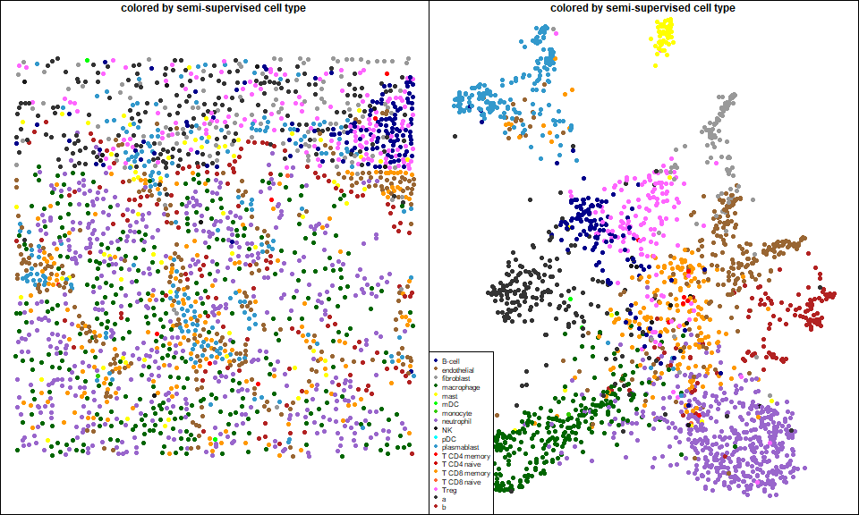

```r
# colors for known cell types:
cols = iocolors
# colors for new clusters
cols["a"] <- "grey20"
cols["b"] <- "firebrick"

par(mfrow = c(1,2))
par(mar = c(0,0,0,0))

plot(mini_nsclc$x, mini_nsclc$y, pch = 16, cex = .75, asp = 1, cex.main = 0.75,
     main = "cells in physical space,\ncolored by semi-supervised cell type",
     col = cols[semi$clust], xlab = "", ylab = "", xaxt = "n", yaxt = "n")

plot(mini_nsclc$umap, pch = 16, cex = .75, asp = 1, cex.main = 0.75,
     main = "cells in UMAP space,\ncolored by semi-supervised cell type",
     col = cols[semi$clust], xlab = "", ylab = "", xaxt = "n", yaxt = "n")
legend("bottomleft", pch = 16, col = cols, legend = names(cols), cex = 0.5)
```

#### Choosing anchor cells for semi-supervised clustering

In the above example of semi-supervised clustering, we let insitutype automatically choose anchor cells. Here we’ll show how to select anchor cells ahead of insitutype. Anchor cells can be selected automatically with the function find_anchor_cells, or they can be selected by hand.

Now let’s see how the find_anchor_cells function works:

```r
anchors <- find_anchor_cells(counts = mini_nsclc$counts,
                             neg = Matrix::rowMeans(mini_nsclc$neg),
                             profiles = ioprofiles,
                             n_cells = 10,
                             min_cosine = 0.3,
                             min_scaled_llr = 0.01)
```

```
#> The following genes in the count data are missing from fixed_profiles and will be omitted from anchor selection: CCL15,CCL18,CCL23,CCL3,CCL3L3,CCL4,CCL4L2,CCL5,CD24,CYTOR,FCGBP,FYB1,GDF10,H2AZ1,H4C3,LINC02446,MMP12,MRC1,MSMB,PECAM1,PRSS2,SELENOP,VEGFD,VSIR
```

```r
str(anchors)
```

```
#>  Named chr [1:2198] NA NA NA NA NA NA NA NA NA "plasmablast" NA NA NA NA NA ...
#>  - attr(*, "names")= chr [1:2198] "c_3_18_2" "c_3_18_3" "c_3_18_4" "c_3_18_5" ...
```

The output is a vector of cells’ “anchor” assignments. Cells not chosen as anchors are given NA entries.

Below are the anchor cells selected. For each cell type, the top 10 cells have been chosen, based on both cosine similarity to a fixed profile and likelihood ratio vs. other cell types.

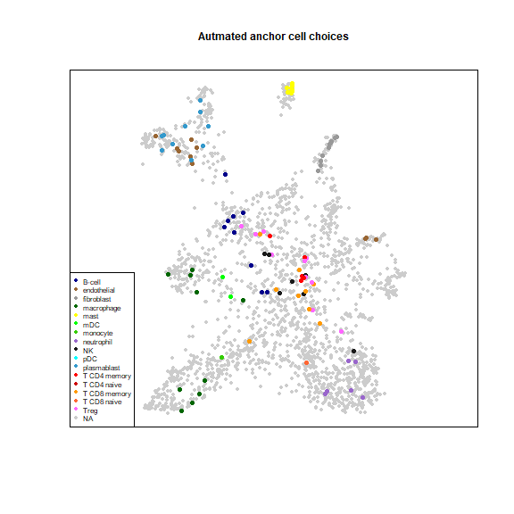

```r
cols = iocolors
cols["NA"] = "grey80"

plot(mini_nsclc$umap, pch = 16, cex = .5, asp = 1, cex.main = 0.75,
     main = "Autmated anchor cell choices", col = "grey80",
     xlab = "", ylab = "", xaxt = "n", yaxt = "n")
points(mini_nsclc$umap, pch = 16, cex = .75,
     col = cols[anchors])
legend("bottomleft", pch = 16, col = cols, legend = names(cols), cex = 0.5)
```

#### Visualizing clustering results

Insitutype calculates the probability of each cell belonging to each cluster. This information lets us understand how clusters relate to each other. The flightpath_plot function arrays cells according to their cluster probabilities:

```r
cols <- c('#8DD3C7','#BEBADA','#FB8072','#80B1D3','#FDB462','#B3DE69','#FCCDE5','#D9D9D9','#BC80BD','#CCEBC5','#FFED6F','#E41A1C','#377EB8','#4DAF4A','#984EA3','#FF7F00','#FFFF33','#A65628','#F781BF','#999999')
cols <- cols[seq_along(unique(unsup$clust))]
names(cols) <- unique(unsup$clust)
fp <- flightpath_plot(flightpath_result = NULL, insitutype_result = unsup, col = cols[unsup$clust])
class(fp)
```

```
#> [1] "gg"     "ggplot"
```

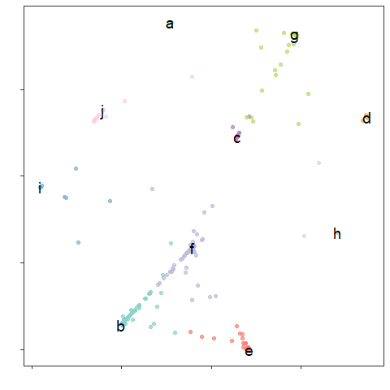

```r
print(fp)
```

Here we can see that clusters b and f are often confused.

#### Merging closely related cell types

Sometimes it becomes clear that two clusters come from the same cell type. When this happens, it can be convenient to merge them.

To get new cell type probabilities from merged cell types, use the mergeCells function:

```r
newprobs <- mergeCells(merges = c("a" = "newcluster", "b" = "newcluster"),
                       probs = unsup$probs)
str(newprobs)
```

```
#> List of 2
#>  $ clust: Named chr [1:2198] "newcluster" "newcluster" "newcluster" "newcluster" ...
#>   ..- attr(*, "names")= chr [1:2198] "c_3_18_2" "c_3_18_3" "c_3_18_4" "c_3_18_5" ...
#>  $ probs: num [1:2198, 1:9] 1 1 1 1 0 0 0 0.93 0 0 ...
#>   ..- attr(*, "dimnames")=List of 2
#>   .. ..$ : chr [1:2198] "c_3_18_2" "c_3_18_3" "c_3_18_4" "c_3_18_5" ...
#>   .. ..$ : chr [1:9] "newcluster" "f" "e" "i" ...
```